# How to connect R to the Toggl API

## Rationale

I became overwhelmed with the amount of work that I have to do, and felt that I do not have any free time. This is obvously not true and to visualise my procrastination practices I decided to track each second of my time for the next few weeks.

The Toggl is a great tool to track time. The only problem I had with its online platform is that one can not easily get the all important info from it, and being a researcher - graphing is a big issue for me, so I can NOT accept pie chart plots. They are ok for fast visualisation but I felt I will require something more powerful - like R and ggplot!

To be able to access my data I figured that they could be loaded into R using the Toggl API.

This post is my try (also a pure procrastination) to minimise my procrastination practices using easily accessible data that will tell me where I am doing the worst and which parts of my routine have to bo reviewed.

First we will need our API token - which can be found online in our account settings.

https://www.toggl.com/app/profile

```r
key  <- '3e2bdcf7243ce719f67b39a2fae01076'
```

We allso need communication which is done by httr package This package enables us to use calls like the CURL functions under linux. The calling is jus slightly different.

Now to get time enteries in the specific range we will need times in ISO 8601 format.

```r
start <- "2015-01-01T00:00:00+02:00"
end <- "2016-01-19T00:00:00+02:00"
```

And here is my fnction which will give you the dataframe of your time enteries.

```r
get_toggl_enteries <- function(start,end,api_token){
    #Base64 is requirec for communication with the API because it encodes the username:password
    require(base64enc)
    key <- api_token
    #make the key conformant with the requirements of the API
    keys <- charToRaw(paste0(key,":api_token"))
    auth <- paste0("Basic ",base64encode(keys))
    #we will use httr to get responses from the server
    require(httr)
    #First get to the proper url
    TE <- "https://www.toggl.com/api/v8/time_entries"
    enteries <-GET(url = TE,
                   #the dates go into the query
               query= list(start_date=start,
                           end_date=end),
               #Authorization into the header
               add_headers (Authorization = auth)
#                verbose()
               )
    require(RJSONIO)
    #now we will create a database out of the downloaded enteries
    Jent<- rawToChar(enteries$content) # This is a JSON file
    #Getting rid of these ugly null values
    json <- fromJSON(Jent,nullValue = NA)
    # Replace (empty) lists by NA and convert to data frames:

    dat <- lapply(json, function(j) {
    as.data.frame(replace(j, sapply(j, is.list), NA))
    })
    # Create a single data frame:

    require(plyr)
    res <- rbind.fill(dat)

    return(res)
}

enteries <- get_toggl_enteries(start,end,key)
```

Now with such a nice database we can plot what we want. For example the summarized ammount of time we spent on a certain task type:

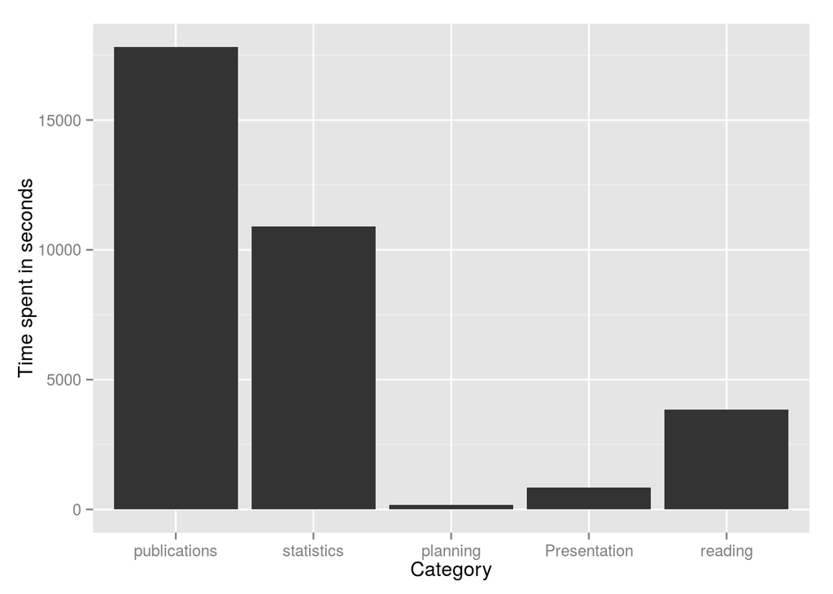

```r
require(ggplot2)
qplot(tags, data=enteries[!is.na(enteries$tags),], geom="bar", weight = duration,xlab="Category", ylab="Time spent in seconds")
```

You can see that I am not doing enough planning. And this is probably the reason why I am having anxiety that I will not be able to finish everything that is on my plate.

But if we add procrastination tasks into this picture:

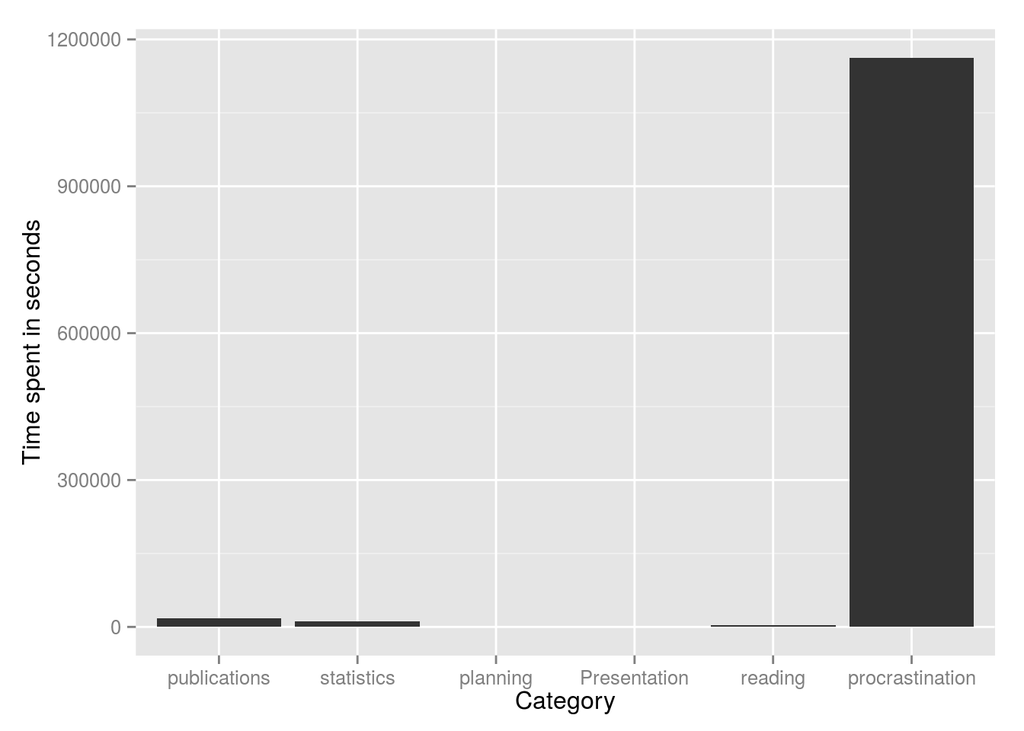

```r
levels(enteries$tags) <- c(levels(enteries$tags),"procrastination")
enteries$tags[is.na(enteries$tags)] <- "procrastination"
qplot(tags, data=enteries[!is.na(enteries$tags),], geom="bar", weight = duration,xlab="Category", ylab="Time spent in seconds")
```

We can only see how time is wasted…

So enough procrastinating. Off to some really important assignments… Ugh…